# Lab 4

Neha Maddali

10/21/2021

```r
library(readxl)
library(ggplot2)
library(dplyr)
library(tidyverse)
defense <- read_excel('./cyclonesFootball2020.xlsx', sheet='Defensive')
offense <- read_excel('./cyclonesFootball2020.xlsx', sheet='Offensive')
bio <- read_excel('./cyclonesFootball2020.xlsx', sheet='Biography')
```

```r
str(defense)
```

```
## tibble [372 x 11] (S3: tbl_df/tbl/data.frame)
##  $ Name             : chr [1:372] "Rose, Mike" "Rose, Mike" "Rose, Mike" "Rose, Mike" ...
##  $ Opponent_Opponent: chr [1:372] "Louisiana" "TCU" "Oklahoma" "Texas Tech" ...
##  $ Tackles_Solo     : chr [1:372] "2" "6" "6" "3" ...
##  $ Tackles_ASST     : chr [1:372] "4" "4" "5" "0" ...
##  $ Tackles_TFL      : chr [1:372] "1.0" "0" "1.5" "1.0" ...
##  $ Tackles_Sack     : chr [1:372] "0" "0" "0.5" "0" ...
##  $ Turnover_FF      : chr [1:372] "0" "0" "0" "0" ...
##  $ Turnover_FR      : chr [1:372] "0" "0" "0" "0" ...
##  $ Turnover_INT     : chr [1:372] "0" "1" "0" "0" ...
##  $ Pass_QBH         : chr [1:372] "0" "0" "1" "0" ...
##  $ Pass_PB          : chr [1:372] "0" "0" "0" "0" ...
```

```r
str(offense)
```

```
## tibble [156 x 12] (S3: tbl_df/tbl/data.frame)
##  $ Name             : chr [1:156] "Akers, Landen" "Akers, Landen" "Akers, Landen" "Akers, Landen" ...
##  $ Opponent_Opponent: chr [1:156] "Louisiana" "TCU" "Oklahoma" "Texas Tech" ...
##  $ Receiving_REC    : chr [1:156] "0" "2" "1" "4" ...
##  $ Receiving_YDS    : chr [1:156] "0" "60" "35" "34" ...
##  $ Receiving_TD     : chr [1:156] "0" "0" "0" "0" ...
##  $ Rushing_ATT      : chr [1:156] NA NA NA NA ...
##  $ Rushing_YDS      : chr [1:156] NA NA NA NA ...
##  $ Rushing_TD       : chr [1:156] NA NA NA NA ...
##  $ Passing_CMP-ATT  : chr [1:156] NA NA NA NA ...
##  $ Passing_YDS      : chr [1:156] NA NA NA NA ...
##  $ Passing_TD       : chr [1:156] NA NA NA NA ...
##  $ Passing_INT      : chr [1:156] NA NA NA NA ...
```

```r
str(bio)
```

```
## tibble [116 x 7] (S3: tbl_df/tbl/data.frame)
##  $ Name      : chr [1:116] "Akers, Landen" "Allen, Chase" "Anderson, Ezeriah" "Antoine Jr. , Michal" ...
##  $ Position  : chr [1:116] "Wide Receiver" "Tight End" "Wide Receiver" "Defensive Back" ...
##  $ Height    : chr [1:116] "6-0" "6-7" "6-5" "6-0" ...
##  $ Weight    : chr [1:116] "191" "240" "208" "180" ...
##  $ Class     : chr [1:116] "Redshirt Senior" "Redshirt Senior" "Redshirt Freshman" "Freshman" ...
##  $ Hometown  : chr [1:116] "Cedar Rapids, Iowa" "Nixa, Mo." "Seffner, Fla." "Ft. Lauderdale, Fla." ...
##  $ Highschool: chr [1:116] "Washington" "Nixa" "Armwood" "Cardinal Gibbons" ...
```

## Part 1: Cleaning Data

**Question 1** The player names and opponent names should be factors.

```r
defense %>%
  factor('Name','Opponent_Opponent')
```

```
##              Name Opponent_Opponent      Tackles_Solo      Tackles_ASST
##              <NA>              <NA>              <NA>              <NA>
##       Tackles_TFL      Tackles_Sack       Turnover_FF       Turnover_FR
##              <NA>              <NA>              <NA>              <NA>
##      Turnover_INT          Pass_QBH           Pass_PB
##              <NA>              <NA>              <NA>
## Levels: Opponent_Opponent
```

```r
offense %>%
  factor('Name', 'Oppenent_Opponent')
```

```
##              Name Opponent_Opponent     Receiving_REC     Receiving_YDS
##              <NA>              <NA>              <NA>              <NA>
##      Receiving_TD       Rushing_ATT       Rushing_YDS        Rushing_TD
##              <NA>              <NA>              <NA>              <NA>
##   Passing_CMP-ATT       Passing_YDS        Passing_TD       Passing_INT
##              <NA>              <NA>              <NA>              <NA>
## Levels: Oppenent_Opponent
```

```r
bio %>%
  factor('Name')
```

```
##       Name   Position     Height     Weight      Class   Hometown Highschool
##       <NA>       <NA>       <NA>       <NA>       <NA>       <NA>       <NA>
## Levels: Name
```

**Question 2** All offensive and defensive statistics should be numerical. The Weight column in biogrpahy should also be numeric. (Optional: Read ?across and learn to mutate multiple columns simultaneously using the across function in dplyr)

```r
defense <- defense %>%
  mutate(across(Tackles_Solo:Pass_PB, as.numeric))

offense <- offense %>%
  mutate(across(Receiving_REC: Passing_INT, as.numeric))
bio <- bio %>%
  mutate(across(Weight, as.numeric))
```

**Question 3** The Height column in biography should be numeric. (Hint: Use a unit that works well)

```r
bio <- bio %>%
  separate(Height,c('feet', 'inches'), sep = '-', convert = TRUE, remove = FALSE) %>%
  mutate(Height = 12*feet + inches) %>%
  select(-feet) %>%
  select(-inches) %>%
  summarize(Name, Position, HeightInches = Height, Weight, Class, Hometown, Highschool)
```

**Question 4** Add a column to both defense and offense indicating whether it is the first or the second game versus an opponent. We had a single game versus each opponent except for Oklahoma, which we played against twice. (Hint: You can use group_by(), mutate(), and row_number())

```r
defense <- defense %>%
  group_by(Name, Opponent_Opponent) %>%
  mutate(Game = row_number())

offense <- offense %>%
  group_by(Name, Opponent_Opponent) %>%
  mutate(Game = row_number())

defClean <- defense
offClean <- offense
bioClean <- bio

str(defClean)
```

[output not shown]

[output cut: 64 more lines]

```
##   .. ..$ : int 296
##   .. ..$ : int 157
##   .. ..$ : int 156
##   .. ..$ : int 158
##   .. ..$ : int [1:2] 153 161
##   .. ..$ : int 155
##   .. ..$ : int 162
##   .. ..$ : int 152
##   .. ..$ : int 159
##   .. ..$ : int 154
##   .. ..$ : int 160
##   .. ..$ : int 19
##   .. .. [list output truncated]
##   .. ..@ ptype: int(0)
##   ..- attr(*, ".drop")= logi TRUE
```

```r
str(offClean)
```

[output not shown]

[output cut: 65 more lines]

```
##   .. ..$ : int 135
##   .. ..$ : int 132
##   .. ..$ : int 133
##   .. ..$ : int 41
##   .. ..$ : int 40
##   .. ..$ : int 42
##   .. ..$ : int 35
##   .. ..$ : int [1:2] 37 45
##   .. ..$ : int 39
##   .. ..$ : int 46
##   .. ..$ : int 36
##   .. ..$ : int 43
##   .. .. [list output truncated]
##   .. ..@ ptype: int(0)
##   ..- attr(*, ".drop")= logi TRUE
```

```r
str(bioClean)
```

```
## tibble [116 x 7] (S3: tbl_df/tbl/data.frame)
##  $ Name        : chr [1:116] "Akers, Landen" "Allen, Chase" "Anderson, Ezeriah" "Antoine Jr. , Michal" ...
##  $ Position    : chr [1:116] "Wide Receiver" "Tight End" "Wide Receiver" "Defensive Back" ...
##  $ HeightInches: num [1:116] 72 79 77 72 72 72 75 74 74 74 ...
##  $ Weight      : num [1:116] 191 240 208 180 195 199 253 261 288 182 ...
##  $ Class       : chr [1:116] "Redshirt Senior" "Redshirt Senior" "Redshirt Freshman" "Freshman" ...
##  $ Hometown    : chr [1:116] "Cedar Rapids, Iowa" "Nixa, Mo." "Seffner, Fla." "Ft. Lauderdale, Fla." ...
##  $ Highschool  : chr [1:116] "Washington" "Nixa" "Armwood" "Cardinal Gibbons" ...
```

## Part 2: Tidying and exploring

**Question 1** Reformat the offClean data frame into a tidy format using pivot_longer. The type of statistic (Receiving_REC for the number of receivings, Receiving_YDS for receiving yards, etc) is added as a new key column named stat.

```r
offClean <- offClean %>%
  pivot_longer(Receiving_REC:Passing_INT, names_to = "stat", values_to = "score")
str(offClean)
```

[output not shown]

[output cut: 57 more lines]

```
##   .. ..$ : int [1:10] 1341 1342 1343 1344 1345 1346 1347 1348 1349 1350
##   .. ..$ : int [1:10] 1311 1312 1313 1314 1315 1316 1317 1318 1319 1320
##   .. ..$ : int [1:10] 1321 1322 1323 1324 1325 1326 1327 1328 1329 1330
##   .. ..$ : int [1:10] 401 402 403 404 405 406 407 408 409 410
##   .. ..$ : int [1:10] 391 392 393 394 395 396 397 398 399 400
##   .. ..$ : int [1:10] 411 412 413 414 415 416 417 418 419 420
##   .. ..$ : int [1:10] 341 342 343 344 345 346 347 348 349 350
##   .. ..$ : int [1:20] 361 362 363 364 365 366 367 368 369 370 ...
##   .. ..$ : int [1:10] 381 382 383 384 385 386 387 388 389 390
##   .. ..$ : int [1:10] 451 452 453 454 455 456 457 458 459 460
##   .. ..$ : int [1:10] 351 352 353 354 355 356 357 358 359 360
##   .. ..$ : int [1:10] 421 422 423 424 425 426 427 428 429 430
##   .. .. [list output truncated]
##   .. ..@ ptype: int(0)
##   ..- attr(*, ".drop")= logi TRUE
```

**Question 2** Obtain the player-level offensive statistics. Namely, for each player and each type of statistics, obtain the sum of the statistics in all games.

```r
dat1 <- offClean %>%
  group_by(Name, stat) %>%
  replace(is.na(.), 0) %>%
  summarize(statSum = sum(score))
dat1
```

```
## # A tibble: 160 x 3
## # Groups:   Name [16]
##    Name          stat            statSum
##    <chr>         <chr>             <dbl>
##  1 Akers, Landen Passing_CMP-ATT       0
##  2 Akers, Landen Passing_INT           0
##  3 Akers, Landen Passing_TD            0
##  4 Akers, Landen Passing_YDS           0
##  5 Akers, Landen Receiving_REC        18
##  6 Akers, Landen Receiving_TD          1
##  7 Akers, Landen Receiving_YDS       269
##  8 Akers, Landen Rushing_ATT           0
##  9 Akers, Landen Rushing_TD            0
## 10 Akers, Landen Rushing_YDS           0
## # ... with 150 more rows
```

**Question 3** Show the distributions of the player-level offensive statistics. The distribution of each offensive statistic should be shown in a separate facet. Explain the patterns you see.

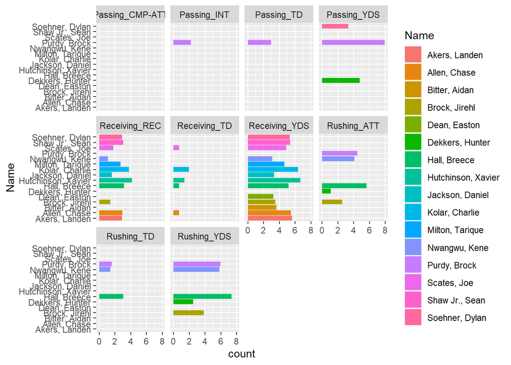

```r
ggplot(dat1, aes(x=Name, weight=log(statSum), fill=Name))+geom_bar()+
  facet_wrap(~stat)+coord_flip()
```

**Question 4** Did ISU have better offense against Oregon or Oklahoma? Answer this question by creating a scatterplot with the x- and y-axes being the receiving yards of the ISU players against each of these two opponents. A large number of receiving yards indicates good offense.

**My Analysis:** ISU had better offense against Oklahoma. Oregon has fewer values, so the comparison of these two data sets aren’t that reliable in my opinion. But Oklahoma has higher stat values.

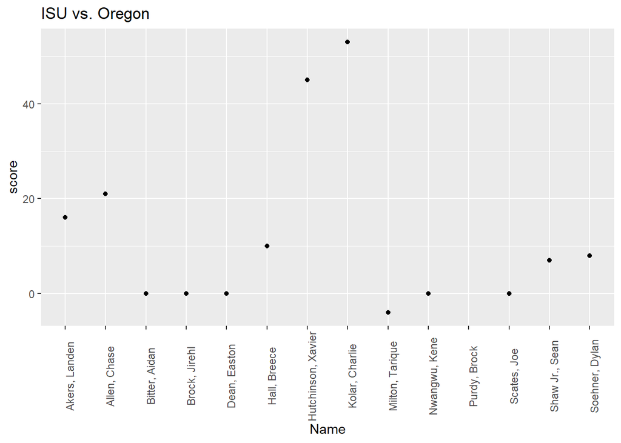

```r
oregon <- offClean %>%
  group_by(Opponent_Opponent) %>%
  filter(Opponent_Opponent=="Oregon") %>%
  filter(stat=="Receiving_YDS")

oklahoma <- offClean %>%
  group_by(Opponent_Opponent) %>%
  filter(Opponent_Opponent=="Oklahoma") %>%
  filter(stat=="Receiving_YDS")

ggplot(oregon, aes(x=Name, y=score)) + geom_point() + labs(title="ISU vs. Oregon") +
  theme(axis.text.x=element_text(angle=90))
```

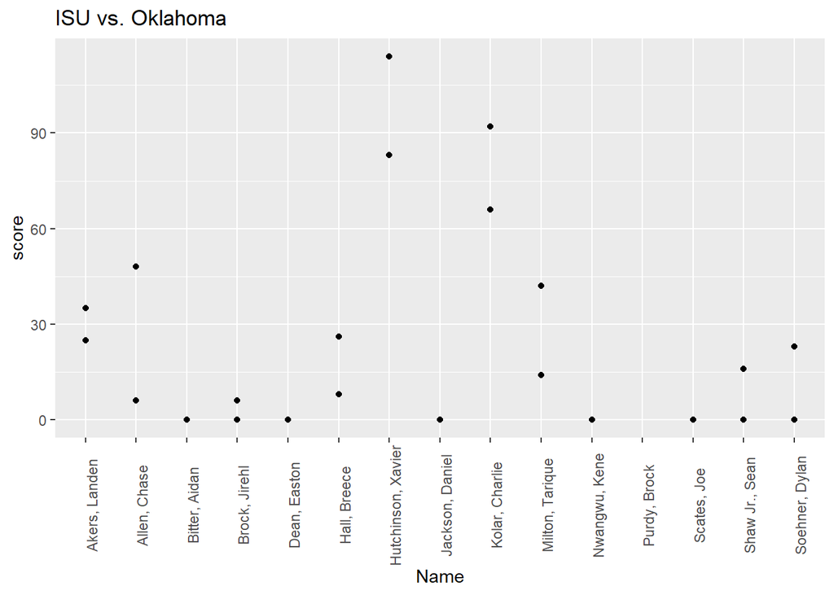

```r
ggplot(oklahoma, aes(x=Name, y=score)) + geom_point() + labs(title="ISU vs. Oklahoma") +
  theme(axis.text.x=element_text(angle=90))
```

**Question 5** Separate the Hometown column into two columns, namely, the city and the state where the player comes from. Print the first few rows of these two columns. (Hint: look at the sep= argument of separate)

```r
bioClean <- bioClean %>%
  separate(Hometown,c('city', 'state'), sep = ',', convert = TRUE, remove = FALSE) %>%
  mutate(City = city) %>%
  mutate(State = state) %>%
  summarize(Name, Position, HeightInches, Weight, Class, Hometown, City, State, Highschool)
str(bioClean)
```

```
## tibble [116 x 9] (S3: tbl_df/tbl/data.frame)
##  $ Name        : chr [1:116] "Akers, Landen" "Allen, Chase" "Anderson, Ezeriah" "Antoine Jr. , Michal" ...
##  $ Position    : chr [1:116] "Wide Receiver" "Tight End" "Wide Receiver" "Defensive Back" ...
##  $ HeightInches: num [1:116] 72 79 77 72 72 72 75 74 74 74 ...
##  $ Weight      : num [1:116] 191 240 208 180 195 199 253 261 288 182 ...
##  $ Class       : chr [1:116] "Redshirt Senior" "Redshirt Senior" "Redshirt Freshman" "Freshman" ...
##  $ Hometown    : chr [1:116] "Cedar Rapids, Iowa" "Nixa, Mo." "Seffner, Fla." "Ft. Lauderdale, Fla." ...
##  $ City        : chr [1:116] "Cedar Rapids" "Nixa" "Seffner" "Ft. Lauderdale" ...
##  $ State       : chr [1:116] " Iowa" " Mo." " Fla." " Fla." ...
##  $ Highschool  : chr [1:116] "Washington" "Nixa" "Armwood" "Cardinal Gibbons" ...
```

**Question 6** How many players are there from each state?

```r
dat3 <- bioClean %>%
  group_by(State) %>%
  summarize(
    statePlayers = n(),
    once = (statePlayers == 1)
  ) %>%
  select(-once)
dat3
```

```
## # A tibble: 21 x 2
##    State        statePlayers
##    <chr>               <int>
##  1 " Ariz."                4
##  2 " Ark."                 1
##  3 " Australia"            1
##  4 " Calif."               2
##  5 " Fla."                14
##  6 " Ga."                  3
##  7 " Ill."                 6
##  8 " Iowa"                42
##  9 " Kan."                 4
## 10 " Mich"                 1
## # ... with 11 more rows
```

**Question 7** How does the performance of quarterback Brock Purdy relate to the performance of the ISU team? Comment on both the defense and offense.

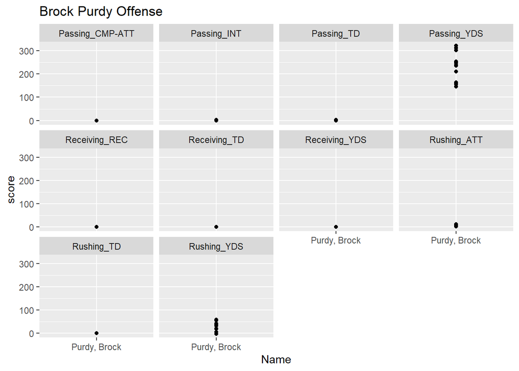

```r
Brock <- offClean %>%
  group_by(stat) %>%
  replace(is.na(.), 0) %>%
  filter(Name=="Purdy, Brock")

Team <- offClean %>%
  group_by(stat) %>%
  replace(is.na(.), 0)

ggplot(Brock, aes(x=Name, y=score)) + geom_point() + labs(title="Brock Purdy Offense") + facet_wrap(~stat)
```

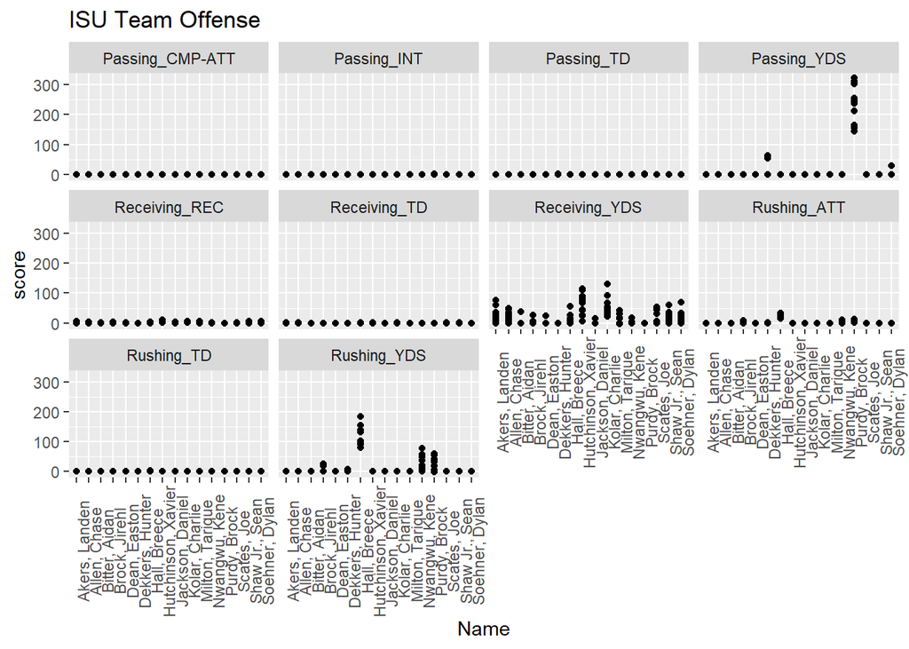

```r
ggplot(Team, aes(x=Name, y=score)) + geom_point() + labs(title="ISU Team Offense") + theme(axis.text.x=element_text(angle = 90)) + facet_wrap(~stat)
```

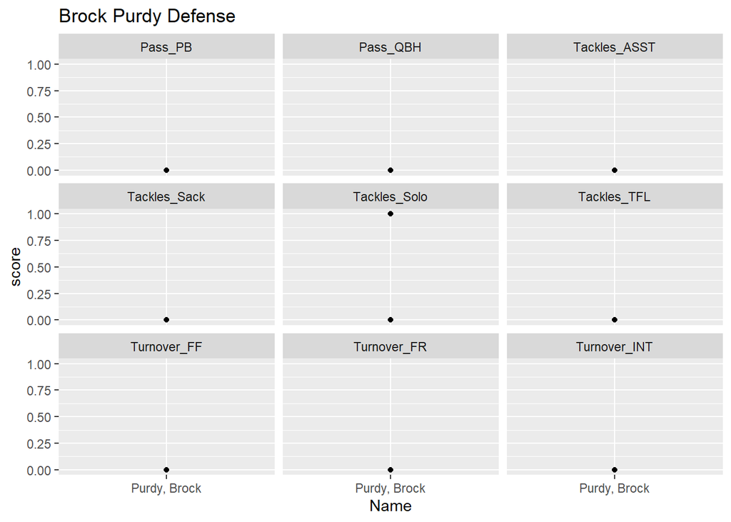

```r
defClean <- defClean %>%
  pivot_longer(Tackles_Solo:Pass_PB, names_to = "stat", values_to = "score")

Brock2 <- defClean %>%
  group_by(stat) %>%
  replace(is.na(.), 0) %>%
  filter(Name=="Purdy, Brock")

Team2 <- defClean %>%
  group_by(stat) %>%
  replace(is.na(.), 0)

ggplot(Brock2, aes(x=Name, y=score)) + geom_point() + labs(title="Brock Purdy Defense") + facet_wrap(~stat)
```

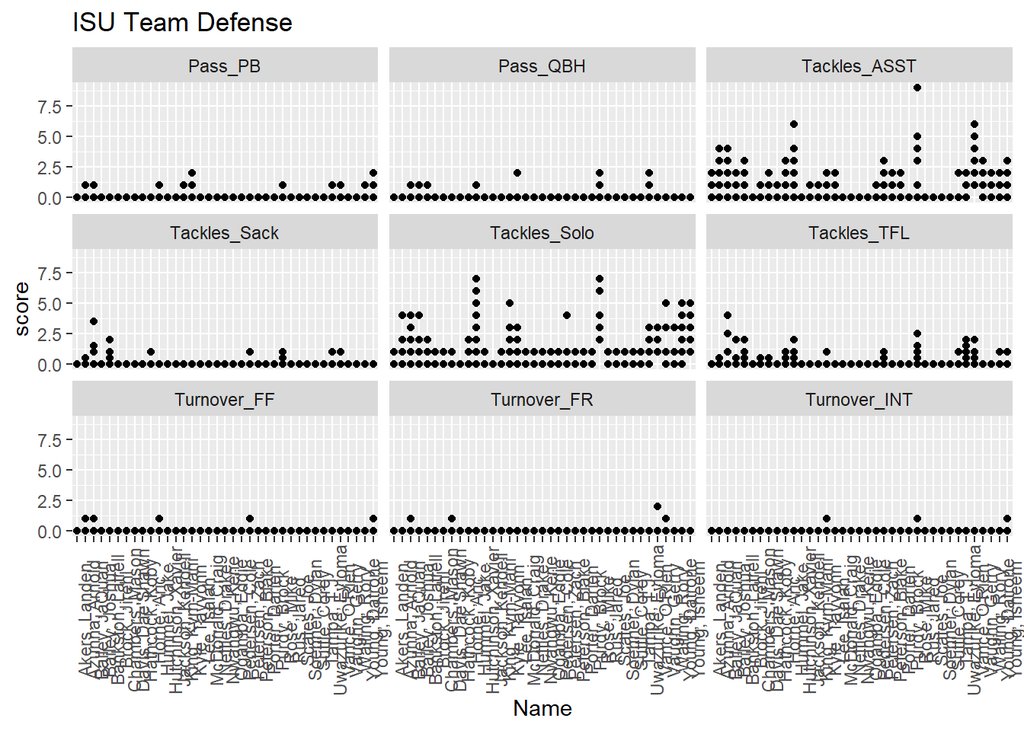

```r
ggplot(Team2, aes(x=Name, y=score)) + geom_point() + labs(title="ISU Team Defense") + theme(axis.text.x=element_text(angle = 90)) + facet_wrap(~stat)
```